# Project 1

Michael Hogsett

2020-09-28

Abstract

This project is all about analysing the SWDEFECTS file using R and probability theory.

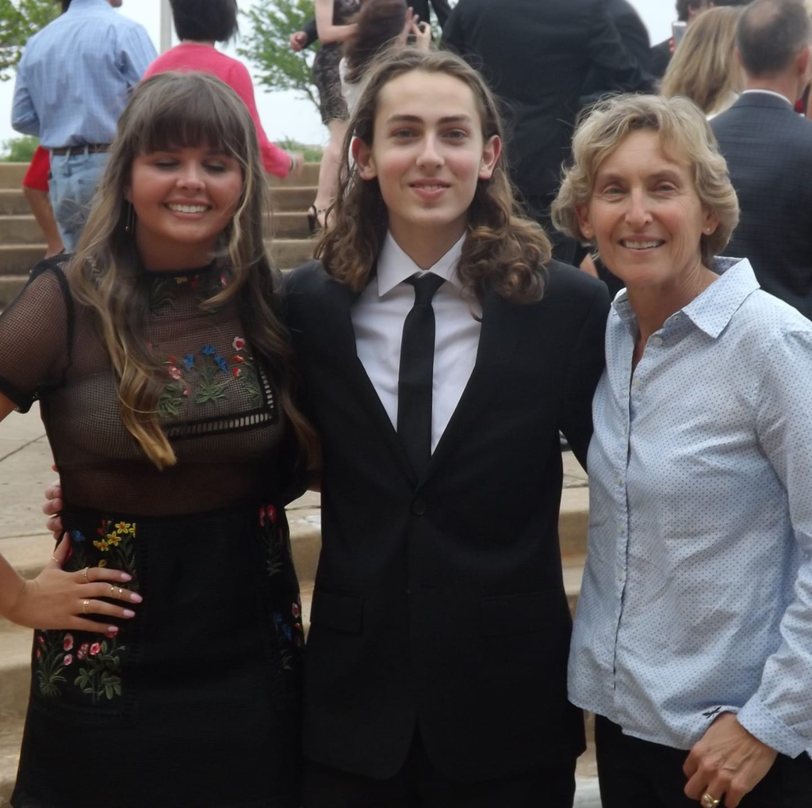

Dr. Wayne Stewart

# 1 Introduction to the data

## 1.1 Data and variables(see MS pg. 77,125)

Describe the data and the problem we wish to investigate.

We will be assessing different methods of detecting defects in software code written for NASA spacecraft instruments. The data contains 498 modules of software code written in “C” language. The software code was evaluated, for defects and classified as “true” (i.e., module has defective code) or “false” (i.e., module has correct code). The SWDEFECTS file contains a variable that corresponds to each method. When the method predicts a defect, the corresponding variable’s value is “yes”. Otherwise, it is “no”.

## 1.2 Summary Table

Create the summary table (TABLE SIA3.2) found on page 125.

```r
getwd()
```

```
## [1] "C:/Users/micha/OneDrive/Desktop/STATS/MATH4753PROJ1"
```

```r
library(data.table)
library(dplyr)
library(formattable)
library(tidyr)
customGreen0 = "#DeF7E9"
customGreen = "#71CA97"
customRed = "#ff7f7f"

table32= fread('Table #1.csv', data.table=FALSE, header = TRUE, stringsAsFactors = FALSE)

head(table32)
```

|  | V1 | V2 | Module Has Defects | V4 |
| --- | --- | --- | --- | --- |
| 1 |  |  | FALSE | TRUE |
| 2 | algorithm | no | a | b |
| 3 | predicts | yes | c | d |
| 4 | defects |  |  |  |

```r
attach(table32)

#1)  First Data Table

formattable(table32,
            align =c("l","c","c","c","c", "c", "c", "c", "r"),
            list(`Indicator Name` = formatter(
              "span", style = ~ style(color = "grey",font.weight = "bold"))
))
```

| V1 | V2 | Module Has Defects | V4 |
| --- | --- | --- | --- |
|  |  | FALSE | TRUE |
| algorithm | no | a | b |
| predicts | yes | c | d |
| defects |  |  |  |

Using $\LaTeX$ construct the formulae for

1. Accuracy
2. Detection rate
3. False alarm rate
4. Precision

$$\begin{eqnarray}
P(Algorithm && is & correct) & = \frac {a+d} {a+b+c+d}
\end{eqnarray}$$
$$\begin{eqnarray}
P(predict && defect & | & module & has & defect) & = \frac {d} {b+d}
\end{eqnarray}$$
$$\begin{eqnarray}
P(predict && defect & | & module & has & no & defect) & = \frac {c} {a+c}
\end{eqnarray}$$
$$\begin{eqnarray}
P(module && has & defect & | & predict & defect) & = \frac {d} {c+d}
\end{eqnarray}$$

# 2 R functions

Using the above definitions make R functions that will create the required probabilities, please remove `eval=FALSE` when creating the functions :

```r
acc=function(a,b,c,d)
{
  isCorrect <- ((a+d)/(a+b+c+d))
  return(isCorrect)

}
```

```r
detect=function(b,d)
{
  hasDefect <- (d/(b+d))
  return(hasDefect)
}
```

```r
falarm=function(a,c)
{
  noDefect <- (c/(a+c))
  return(noDefect)
}
```

```r
prec1=function(c,d)
{
  modDefect <- (d/(c+d))
  return(modDefect)
}
```

# 3 Create the tables in Figure SIA3.1

The tables do not have to be formatted exactly as those in the book. Have the functions produce a suitable barplot also.

As a guide and help – see code below

```r
swd=read.csv("swdefects.csv")
head(swd)
```

|  | Mloc | Mvg | Mevg | Mivg | Hn | Hvol | Hpgmlen | Hdiff | Hintell | Heffort | Hb | Htime | Hloc | Hcomm | Hblank | loc.comm | uniOp | uniOpnd | totOp | totOpnd | brnchcnt | defect | predict.vg.10 | predict.evg.14.5 | predict.ivg.9.2 | predict.loc.50 |
| --- | --- | --- | --- | --- | --- | --- | --- | --- | --- | --- | --- | --- | --- | --- | --- | --- | --- | --- | --- | --- | --- | --- | --- | --- | --- | --- |
| 1 | 1.1 | 1.4 | 1.4 | 1.4 | 1.3 | 1.3 | 1.30 | 1.30 | 1.30 | 1 | 1.30 | 1 | 2 | 2 | 2 | 2 | 1.2 | 1.2 | 1.2 | 1.2 | 1.4 | FALSE | no | no | no | no |
| 2 | 1.0 | 1.0 | 1.0 | 1.0 | 1.0 | 1.0 | 1.00 | 1.00 | 1.00 | 1 | 1.00 | 1 | 1 | 1 | 1 | 1 | 1.0 | 1.0 | 1.0 | 1.0 | 1.0 | TRUE | no | no | no | no |
| 3 | 24.0 | 5.0 | 1.0 | 3.0 | 63.0 | 309.1 | 0.11 | 9.50 | 32.54 | 2937 | 0.10 | 163 | 1 | 0 | 6 | 0 | 15.0 | 15.0 | 44.0 | 19.0 | 9.0 | FALSE | no | no | no | no |
| 4 | 20.0 | 4.0 | 4.0 | 2.0 | 47.0 | 215.5 | 0.06 | 16.00 | 13.47 | 3448 | 0.07 | 192 | 0 | 0 | 3 | 0 | 16.0 | 8.0 | 31.0 | 16.0 | 7.0 | FALSE | no | no | no | no |
| 5 | 24.0 | 6.0 | 6.0 | 2.0 | 72.0 | 346.1 | 0.06 | 17.33 | 19.97 | 6000 | 0.12 | 333 | 0 | 0 | 3 | 0 | 16.0 | 12.0 | 46.0 | 26.0 | 11.0 | FALSE | no | no | no | no |
| 6 | 24.0 | 6.0 | 6.0 | 2.0 | 72.0 | 346.1 | 0.06 | 17.33 | 19.97 | 6000 | 0.12 | 333 | 0 | 0 | 3 | 0 | 16.0 | 12.0 | 46.0 | 26.0 | 11.0 | FALSE | no | no | no | no |

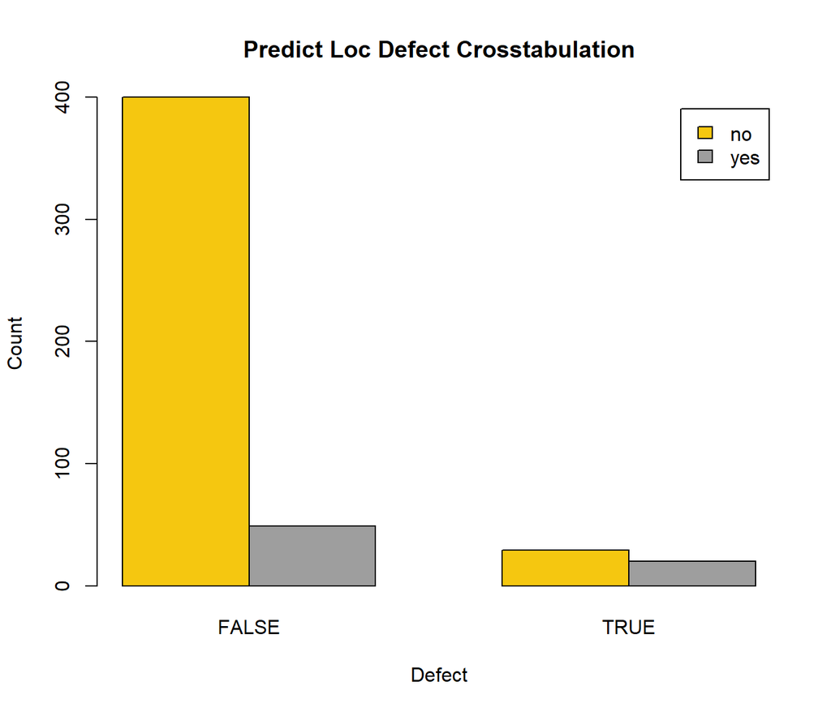

```r
tab=with(swd, table(predict.loc.50,defect))
barplot(tab, beside=TRUE, leg=TRUE,ylab = "Count", main="Predict Loc Defect Crosstabulation", xlab="Defect", col=7:8)
```

```r
tab2=addmargins(tab)
tab2
```

```
##               defect
## predict.loc.50 FALSE TRUE Sum
##            no    400   29 429
##            yes    49   20  69
##            Sum   449   49 498
```

```r
swd=read.csv("swdefects.csv")
head(swd)
```

|  | Mloc | Mvg | Mevg | Mivg | Hn | Hvol | Hpgmlen | Hdiff | Hintell | Heffort | Hb | Htime | Hloc | Hcomm | Hblank | loc.comm | uniOp | uniOpnd | totOp | totOpnd | brnchcnt | defect | predict.vg.10 | predict.evg.14.5 | predict.ivg.9.2 | predict.loc.50 |
| --- | --- | --- | --- | --- | --- | --- | --- | --- | --- | --- | --- | --- | --- | --- | --- | --- | --- | --- | --- | --- | --- | --- | --- | --- | --- | --- |
| 1 | 1.1 | 1.4 | 1.4 | 1.4 | 1.3 | 1.3 | 1.30 | 1.30 | 1.30 | 1 | 1.30 | 1 | 2 | 2 | 2 | 2 | 1.2 | 1.2 | 1.2 | 1.2 | 1.4 | FALSE | no | no | no | no |
| 2 | 1.0 | 1.0 | 1.0 | 1.0 | 1.0 | 1.0 | 1.00 | 1.00 | 1.00 | 1 | 1.00 | 1 | 1 | 1 | 1 | 1 | 1.0 | 1.0 | 1.0 | 1.0 | 1.0 | TRUE | no | no | no | no |
| 3 | 24.0 | 5.0 | 1.0 | 3.0 | 63.0 | 309.1 | 0.11 | 9.50 | 32.54 | 2937 | 0.10 | 163 | 1 | 0 | 6 | 0 | 15.0 | 15.0 | 44.0 | 19.0 | 9.0 | FALSE | no | no | no | no |
| 4 | 20.0 | 4.0 | 4.0 | 2.0 | 47.0 | 215.5 | 0.06 | 16.00 | 13.47 | 3448 | 0.07 | 192 | 0 | 0 | 3 | 0 | 16.0 | 8.0 | 31.0 | 16.0 | 7.0 | FALSE | no | no | no | no |
| 5 | 24.0 | 6.0 | 6.0 | 2.0 | 72.0 | 346.1 | 0.06 | 17.33 | 19.97 | 6000 | 0.12 | 333 | 0 | 0 | 3 | 0 | 16.0 | 12.0 | 46.0 | 26.0 | 11.0 | FALSE | no | no | no | no |
| 6 | 24.0 | 6.0 | 6.0 | 2.0 | 72.0 | 346.1 | 0.06 | 17.33 | 19.97 | 6000 | 0.12 | 333 | 0 | 0 | 3 | 0 | 16.0 | 12.0 | 46.0 | 26.0 | 11.0 | FALSE | no | no | no | no |

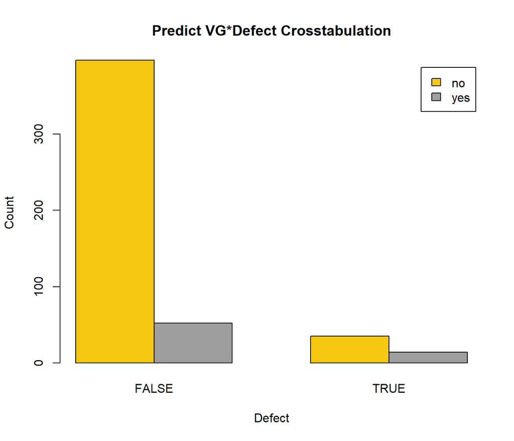

```r
tab=with(swd, table(predict.vg.10,defect))
barplot(tab, beside=TRUE, leg=TRUE,ylab = "Count", main="Predict VG*Defect Crosstabulation", xlab="Defect", col=7:8)
```

```r
tab4=addmargins(tab)
tab4
```

```
##              defect
## predict.vg.10 FALSE TRUE Sum
##           no    397   35 432
##           yes    52   14  66
##           Sum   449   49 498
```

```r
swd=read.csv("swdefects.csv")
head(swd)
```

|  | Mloc | Mvg | Mevg | Mivg | Hn | Hvol | Hpgmlen | Hdiff | Hintell | Heffort | Hb | Htime | Hloc | Hcomm | Hblank | loc.comm | uniOp | uniOpnd | totOp | totOpnd | brnchcnt | defect | predict.vg.10 | predict.evg.14.5 | predict.ivg.9.2 | predict.loc.50 |
| --- | --- | --- | --- | --- | --- | --- | --- | --- | --- | --- | --- | --- | --- | --- | --- | --- | --- | --- | --- | --- | --- | --- | --- | --- | --- | --- |
| 1 | 1.1 | 1.4 | 1.4 | 1.4 | 1.3 | 1.3 | 1.30 | 1.30 | 1.30 | 1 | 1.30 | 1 | 2 | 2 | 2 | 2 | 1.2 | 1.2 | 1.2 | 1.2 | 1.4 | FALSE | no | no | no | no |
| 2 | 1.0 | 1.0 | 1.0 | 1.0 | 1.0 | 1.0 | 1.00 | 1.00 | 1.00 | 1 | 1.00 | 1 | 1 | 1 | 1 | 1 | 1.0 | 1.0 | 1.0 | 1.0 | 1.0 | TRUE | no | no | no | no |
| 3 | 24.0 | 5.0 | 1.0 | 3.0 | 63.0 | 309.1 | 0.11 | 9.50 | 32.54 | 2937 | 0.10 | 163 | 1 | 0 | 6 | 0 | 15.0 | 15.0 | 44.0 | 19.0 | 9.0 | FALSE | no | no | no | no |
| 4 | 20.0 | 4.0 | 4.0 | 2.0 | 47.0 | 215.5 | 0.06 | 16.00 | 13.47 | 3448 | 0.07 | 192 | 0 | 0 | 3 | 0 | 16.0 | 8.0 | 31.0 | 16.0 | 7.0 | FALSE | no | no | no | no |
| 5 | 24.0 | 6.0 | 6.0 | 2.0 | 72.0 | 346.1 | 0.06 | 17.33 | 19.97 | 6000 | 0.12 | 333 | 0 | 0 | 3 | 0 | 16.0 | 12.0 | 46.0 | 26.0 | 11.0 | FALSE | no | no | no | no |
| 6 | 24.0 | 6.0 | 6.0 | 2.0 | 72.0 | 346.1 | 0.06 | 17.33 | 19.97 | 6000 | 0.12 | 333 | 0 | 0 | 3 | 0 | 16.0 | 12.0 | 46.0 | 26.0 | 11.0 | FALSE | no | no | no | no |

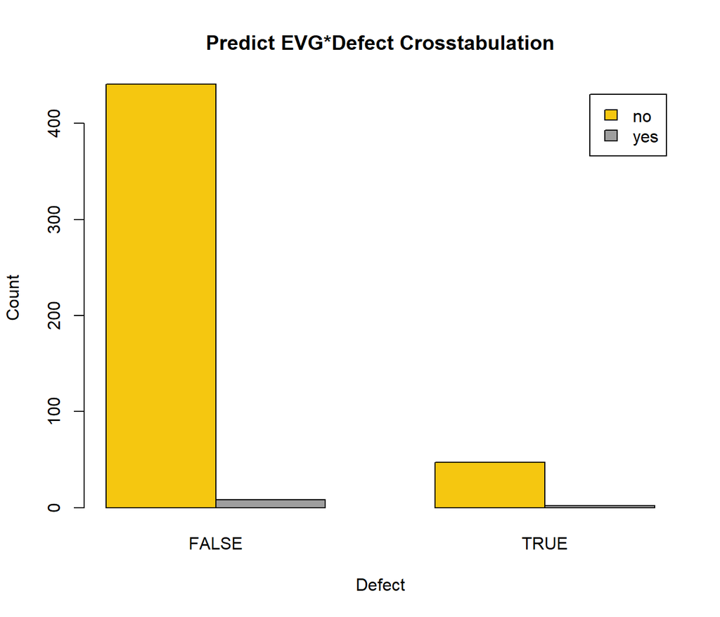

```r
tab=with(swd, table(predict.evg.14.5,defect))

barplot(tab, beside=TRUE, leg=TRUE,ylab = "Count", main="Predict EVG*Defect Crosstabulation", xlab="Defect", col=7:8)
```

```r
tab5=addmargins(tab)
tab5
```

```
##                 defect
## predict.evg.14.5 FALSE TRUE Sum
##              no    441   47 488
##              yes     8    2  10
##              Sum   449   49 498
```

```r
swd=read.csv("swdefects.csv")
head(swd)
```

|  | Mloc | Mvg | Mevg | Mivg | Hn | Hvol | Hpgmlen | Hdiff | Hintell | Heffort | Hb | Htime | Hloc | Hcomm | Hblank | loc.comm | uniOp | uniOpnd | totOp | totOpnd | brnchcnt | defect | predict.vg.10 | predict.evg.14.5 | predict.ivg.9.2 | predict.loc.50 |
| --- | --- | --- | --- | --- | --- | --- | --- | --- | --- | --- | --- | --- | --- | --- | --- | --- | --- | --- | --- | --- | --- | --- | --- | --- | --- | --- |
| 1 | 1.1 | 1.4 | 1.4 | 1.4 | 1.3 | 1.3 | 1.30 | 1.30 | 1.30 | 1 | 1.30 | 1 | 2 | 2 | 2 | 2 | 1.2 | 1.2 | 1.2 | 1.2 | 1.4 | FALSE | no | no | no | no |
| 2 | 1.0 | 1.0 | 1.0 | 1.0 | 1.0 | 1.0 | 1.00 | 1.00 | 1.00 | 1 | 1.00 | 1 | 1 | 1 | 1 | 1 | 1.0 | 1.0 | 1.0 | 1.0 | 1.0 | TRUE | no | no | no | no |
| 3 | 24.0 | 5.0 | 1.0 | 3.0 | 63.0 | 309.1 | 0.11 | 9.50 | 32.54 | 2937 | 0.10 | 163 | 1 | 0 | 6 | 0 | 15.0 | 15.0 | 44.0 | 19.0 | 9.0 | FALSE | no | no | no | no |
| 4 | 20.0 | 4.0 | 4.0 | 2.0 | 47.0 | 215.5 | 0.06 | 16.00 | 13.47 | 3448 | 0.07 | 192 | 0 | 0 | 3 | 0 | 16.0 | 8.0 | 31.0 | 16.0 | 7.0 | FALSE | no | no | no | no |
| 5 | 24.0 | 6.0 | 6.0 | 2.0 | 72.0 | 346.1 | 0.06 | 17.33 | 19.97 | 6000 | 0.12 | 333 | 0 | 0 | 3 | 0 | 16.0 | 12.0 | 46.0 | 26.0 | 11.0 | FALSE | no | no | no | no |
| 6 | 24.0 | 6.0 | 6.0 | 2.0 | 72.0 | 346.1 | 0.06 | 17.33 | 19.97 | 6000 | 0.12 | 333 | 0 | 0 | 3 | 0 | 16.0 | 12.0 | 46.0 | 26.0 | 11.0 | FALSE | no | no | no | no |

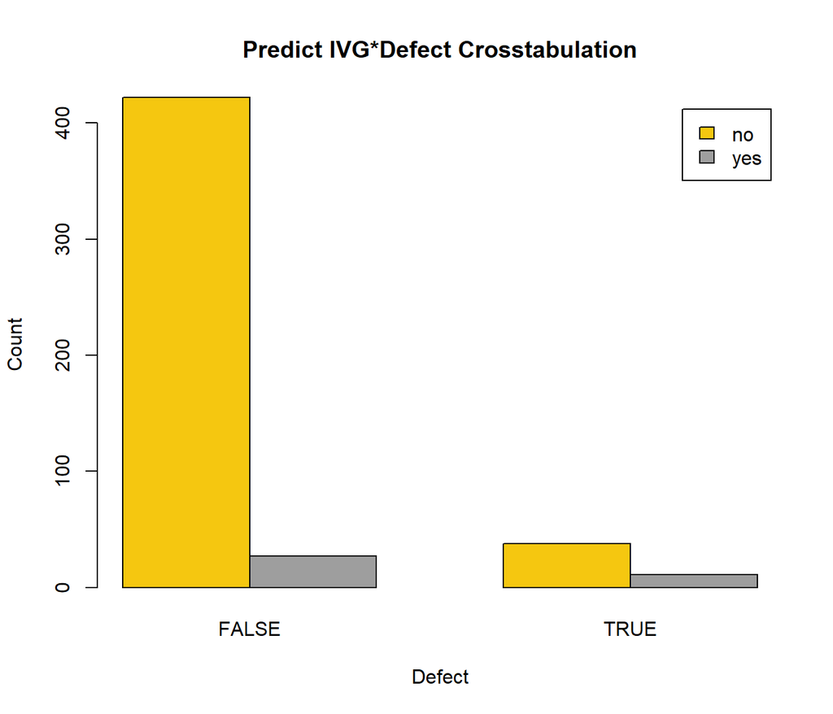

```r
tab=with(swd, table(predict.ivg.9.2,defect))

barplot(tab, beside=TRUE, leg=TRUE,ylab = "Count", main="Predict IVG*Defect Crosstabulation", xlab="Defect", col=7:8)
```

```r
tab6=addmargins(tab)
tab6
```

```
##                defect
## predict.ivg.9.2 FALSE TRUE Sum
##             no    422   38 460
##             yes    27   11  38
##             Sum   449   49 498
```

# 4 Create the corrected table on page 127 (there are mistakes in it), TABLE SIA3.3

Using the functions you have made, create the corrected table (SIA3.3) in an R chunk.

You can call this table `tab3`

Now create a function `mybar()`that will have as its input variables

> 1. tab ( this will be a n by m table) - like `tab3`
> 2. acc ( accuracy of the decimal output ) – like `acc=4` for example

The function will need to create two things

> 1. A barplot of the table
> 2. Commandline output in the form of a list containing the table

```r
accacc<-c(acc(400,29,49,20),acc(397,35,52,14),acc(441,47,8,2),acc(422,38,27,11))
accuracy <- round(accacc,4)
```

```r
detdet<-c(detect(29,20), detect(35,14) ,detect(47,2) ,detect(38,11))

detection.rate <- round(detdet,4)
```

```r
ffal<-c(

falarm(400,49),#loc far
falarm(397,52),
falarm(441,8),
falarm(422,27))

false.alarm.rate <- round(ffal,4)
```

```r
pprc <- c(

prec1(49,20),
prec1(52,14),
prec1(8,2),
prec1(27,11))

precision <- round(pprc,4)
```

```r
methodrow <- c("Lines of Code", "Cyclomatic complexity", "Essential complexity", "Design Complexity" )
row15 <- cbind(accuracy, detection.rate, false.alarm.rate, precision)
```

```r
correct25=read.csv("correct1.csv")
```

```r
tab<- row15
tab3 <- correct25
tab3
```

| ï..method | accuracy | detection.rate | false.alarm.rate | precision |
| --- | --- | --- | --- | --- |
| lines of code | 0.8434 | 0.4082 | 0.1091 | 0.2899 |
| cyclomatic complexity | 0.8253 | 0.2857 | 0.1158 | 0.2121 |
| essential complexity | 0.8896 | 0.0408 | 0.0178 | 0.2000 |
| design complexity | 0.8694 | 0.2245 | 0.0601 | 0.2895 |

[figure not shown]

```r
mybar=function(tab,acc)

{
barplot(tab, beside = TRUE, legend.text = methodrow, col=1:4)
  list(prjct1=tab3)

}
```

# Project 1

Michael Hogsett

2020-09-28

Abstract

This project is all about analysing the SWDEFECTS file using R and probability theory.

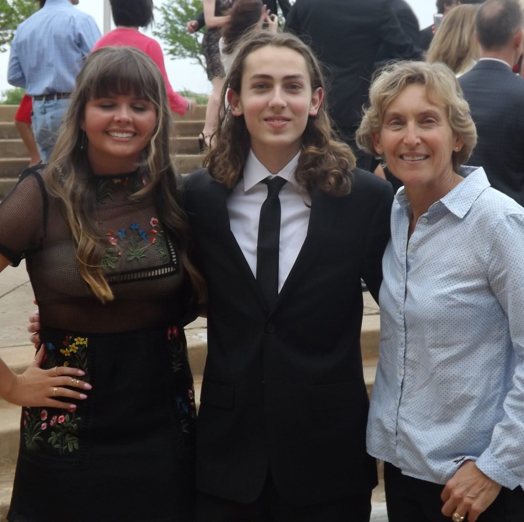

Dr. Wayne Stewart

# 1 Introduction to the data

## 1.1 Data and variables(see MS pg. 77,125)

Describe the data and the problem we wish to investigate.

We will be assessing different methods of detecting defects in software code written for NASA spacecraft instruments. The data contains 498 modules of software code written in “C” language. The software code was evaluated, for defects and classified as “true” (i.e., module has defective code) or “false” (i.e., module has correct code). The SWDEFECTS file contains a variable that corresponds to each method. When the method predicts a defect, the corresponding variable’s value is “yes”. Otherwise, it is “no”.

## 1.2 Summary Table

Create the summary table (TABLE SIA3.2) found on page 125.

```r
getwd()
```

```
## [1] "C:/Users/micha/OneDrive/Desktop/STATS/MATH4753PROJ1"
```

```r
library(data.table)
library(dplyr)
library(formattable)
library(tidyr)
customGreen0 = "#DeF7E9"
customGreen = "#71CA97"
customRed = "#ff7f7f"

table32= fread('Table #1.csv', data.table=FALSE, header = TRUE, stringsAsFactors = FALSE)

head(table32)
```

|  | V1 | V2 | Module Has Defects | V4 |
| --- | --- | --- | --- | --- |
| 1 |  |  | FALSE | TRUE |
| 2 | algorithm | no | a | b |
| 3 | predicts | yes | c | d |
| 4 | defects |  |  |  |

```r
attach(table32)

#1)  First Data Table

formattable(table32,
            align =c("l","c","c","c","c", "c", "c", "c", "r"),
            list(`Indicator Name` = formatter(
              "span", style = ~ style(color = "grey",font.weight = "bold"))
))
```

| V1 | V2 | Module Has Defects | V4 |
| --- | --- | --- | --- |
|  |  | FALSE | TRUE |
| algorithm | no | a | b |
| predicts | yes | c | d |
| defects |  |  |  |

Using $\LaTeX$ construct the formulae for

1. Accuracy
2. Detection rate
3. False alarm rate
4. Precision

$$\begin{eqnarray}
P(Algorithm && is & correct) & = \frac {a+d} {a+b+c+d}
\end{eqnarray}$$
$$\begin{eqnarray}
P(predict && defect & | & module & has & defect) & = \frac {d} {b+d}
\end{eqnarray}$$
$$\begin{eqnarray}
P(predict && defect & | & module & has & no & defect) & = \frac {c} {a+c}
\end{eqnarray}$$
$$\begin{eqnarray}
P(module && has & defect & | & predict & defect) & = \frac {d} {c+d}
\end{eqnarray}$$

# 2 R functions

Using the above definitions make R functions that will create the required probabilities, please remove `eval=FALSE` when creating the functions :

```r
acc=function(a,b,c,d)
{
  isCorrect <- ((a+d)/(a+b+c+d))
  return(isCorrect)

}
```

```r
detect=function(b,d)
{
  hasDefect <- (d/(b+d))
  return(hasDefect)
}
```

```r
falarm=function(a,c)
{
  noDefect <- (c/(a+c))
  return(noDefect)
}
```

```r
prec1=function(c,d)
{
  modDefect <- (d/(c+d))
  return(modDefect)
}
```

# 3 Create the tables in Figure SIA3.1

The tables do not have to be formatted exactly as those in the book. Have the functions produce a suitable barplot also.

As a guide and help – see code below

```r
swd=read.csv("swdefects.csv")
head(swd)
```

|  | Mloc | Mvg | Mevg | Mivg | Hn | Hvol | Hpgmlen | Hdiff | Hintell | Heffort | Hb | Htime | Hloc | Hcomm | Hblank | loc.comm | uniOp | uniOpnd | totOp | totOpnd | brnchcnt | defect | predict.vg.10 | predict.evg.14.5 | predict.ivg.9.2 | predict.loc.50 |
| --- | --- | --- | --- | --- | --- | --- | --- | --- | --- | --- | --- | --- | --- | --- | --- | --- | --- | --- | --- | --- | --- | --- | --- | --- | --- | --- |
| 1 | 1.1 | 1.4 | 1.4 | 1.4 | 1.3 | 1.3 | 1.30 | 1.30 | 1.30 | 1 | 1.30 | 1 | 2 | 2 | 2 | 2 | 1.2 | 1.2 | 1.2 | 1.2 | 1.4 | FALSE | no | no | no | no |
| 2 | 1.0 | 1.0 | 1.0 | 1.0 | 1.0 | 1.0 | 1.00 | 1.00 | 1.00 | 1 | 1.00 | 1 | 1 | 1 | 1 | 1 | 1.0 | 1.0 | 1.0 | 1.0 | 1.0 | TRUE | no | no | no | no |
| 3 | 24.0 | 5.0 | 1.0 | 3.0 | 63.0 | 309.1 | 0.11 | 9.50 | 32.54 | 2937 | 0.10 | 163 | 1 | 0 | 6 | 0 | 15.0 | 15.0 | 44.0 | 19.0 | 9.0 | FALSE | no | no | no | no |
| 4 | 20.0 | 4.0 | 4.0 | 2.0 | 47.0 | 215.5 | 0.06 | 16.00 | 13.47 | 3448 | 0.07 | 192 | 0 | 0 | 3 | 0 | 16.0 | 8.0 | 31.0 | 16.0 | 7.0 | FALSE | no | no | no | no |
| 5 | 24.0 | 6.0 | 6.0 | 2.0 | 72.0 | 346.1 | 0.06 | 17.33 | 19.97 | 6000 | 0.12 | 333 | 0 | 0 | 3 | 0 | 16.0 | 12.0 | 46.0 | 26.0 | 11.0 | FALSE | no | no | no | no |
| 6 | 24.0 | 6.0 | 6.0 | 2.0 | 72.0 | 346.1 | 0.06 | 17.33 | 19.97 | 6000 | 0.12 | 333 | 0 | 0 | 3 | 0 | 16.0 | 12.0 | 46.0 | 26.0 | 11.0 | FALSE | no | no | no | no |

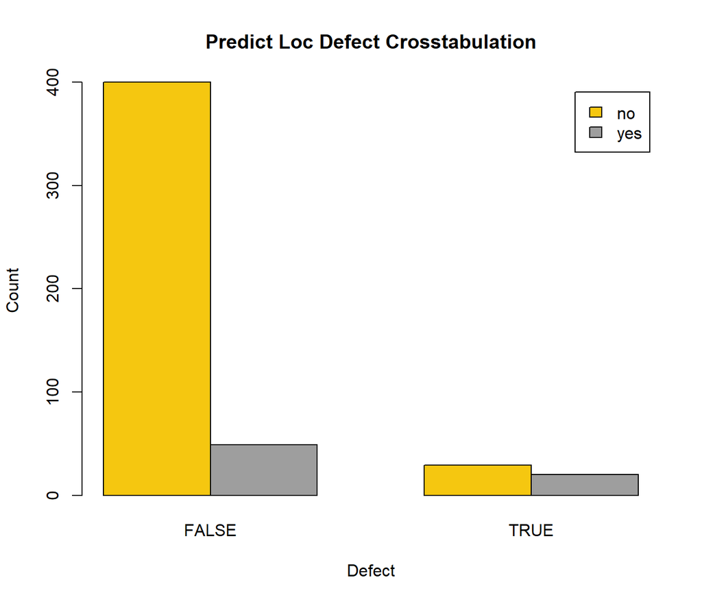

```r
tab=with(swd, table(predict.loc.50,defect))
barplot(tab, beside=TRUE, leg=TRUE,ylab = "Count", main="Predict Loc Defect Crosstabulation", xlab="Defect", col=7:8)
```

```r
tab2=addmargins(tab)
tab2
```

```
##               defect
## predict.loc.50 FALSE TRUE Sum
##            no    400   29 429
##            yes    49   20  69
##            Sum   449   49 498
```

```r
swd=read.csv("swdefects.csv")
head(swd)
```

|  | Mloc | Mvg | Mevg | Mivg | Hn | Hvol | Hpgmlen | Hdiff | Hintell | Heffort | Hb | Htime | Hloc | Hcomm | Hblank | loc.comm | uniOp | uniOpnd | totOp | totOpnd | brnchcnt | defect | predict.vg.10 | predict.evg.14.5 | predict.ivg.9.2 | predict.loc.50 |
| --- | --- | --- | --- | --- | --- | --- | --- | --- | --- | --- | --- | --- | --- | --- | --- | --- | --- | --- | --- | --- | --- | --- | --- | --- | --- | --- |
| 1 | 1.1 | 1.4 | 1.4 | 1.4 | 1.3 | 1.3 | 1.30 | 1.30 | 1.30 | 1 | 1.30 | 1 | 2 | 2 | 2 | 2 | 1.2 | 1.2 | 1.2 | 1.2 | 1.4 | FALSE | no | no | no | no |
| 2 | 1.0 | 1.0 | 1.0 | 1.0 | 1.0 | 1.0 | 1.00 | 1.00 | 1.00 | 1 | 1.00 | 1 | 1 | 1 | 1 | 1 | 1.0 | 1.0 | 1.0 | 1.0 | 1.0 | TRUE | no | no | no | no |
| 3 | 24.0 | 5.0 | 1.0 | 3.0 | 63.0 | 309.1 | 0.11 | 9.50 | 32.54 | 2937 | 0.10 | 163 | 1 | 0 | 6 | 0 | 15.0 | 15.0 | 44.0 | 19.0 | 9.0 | FALSE | no | no | no | no |
| 4 | 20.0 | 4.0 | 4.0 | 2.0 | 47.0 | 215.5 | 0.06 | 16.00 | 13.47 | 3448 | 0.07 | 192 | 0 | 0 | 3 | 0 | 16.0 | 8.0 | 31.0 | 16.0 | 7.0 | FALSE | no | no | no | no |
| 5 | 24.0 | 6.0 | 6.0 | 2.0 | 72.0 | 346.1 | 0.06 | 17.33 | 19.97 | 6000 | 0.12 | 333 | 0 | 0 | 3 | 0 | 16.0 | 12.0 | 46.0 | 26.0 | 11.0 | FALSE | no | no | no | no |
| 6 | 24.0 | 6.0 | 6.0 | 2.0 | 72.0 | 346.1 | 0.06 | 17.33 | 19.97 | 6000 | 0.12 | 333 | 0 | 0 | 3 | 0 | 16.0 | 12.0 | 46.0 | 26.0 | 11.0 | FALSE | no | no | no | no |

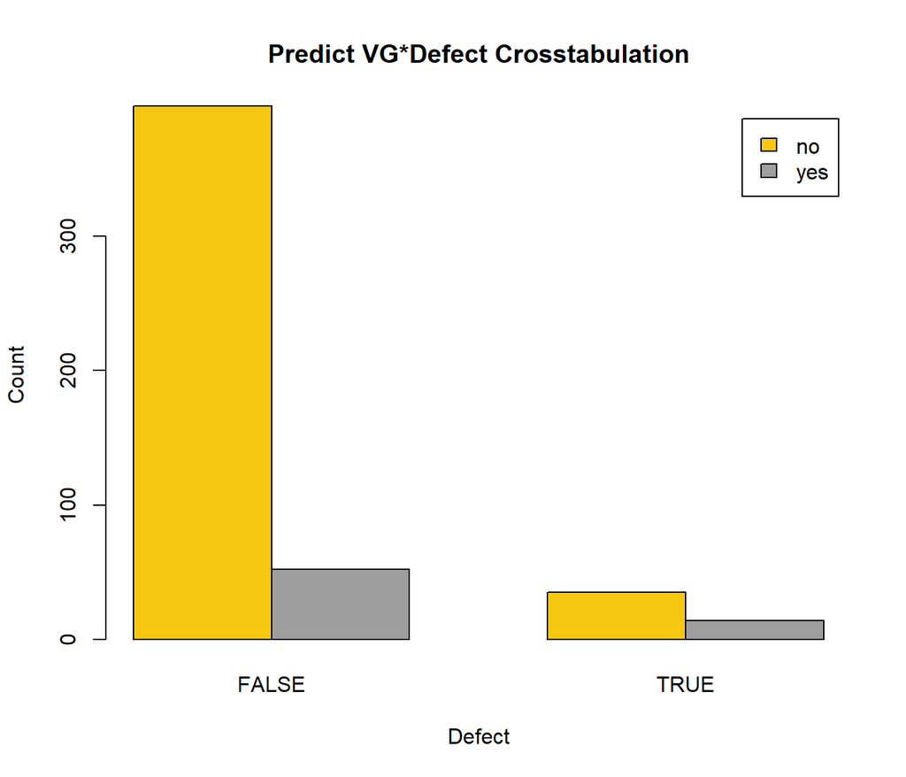

```r
tab=with(swd, table(predict.vg.10,defect))
barplot(tab, beside=TRUE, leg=TRUE,ylab = "Count", main="Predict VG*Defect Crosstabulation", xlab="Defect", col=7:8)
```

```r
tab4=addmargins(tab)
tab4
```

```
##              defect
## predict.vg.10 FALSE TRUE Sum
##           no    397   35 432
##           yes    52   14  66
##           Sum   449   49 498
```

```r
swd=read.csv("swdefects.csv")
head(swd)
```

|  | Mloc | Mvg | Mevg | Mivg | Hn | Hvol | Hpgmlen | Hdiff | Hintell | Heffort | Hb | Htime | Hloc | Hcomm | Hblank | loc.comm | uniOp | uniOpnd | totOp | totOpnd | brnchcnt | defect | predict.vg.10 | predict.evg.14.5 | predict.ivg.9.2 | predict.loc.50 |
| --- | --- | --- | --- | --- | --- | --- | --- | --- | --- | --- | --- | --- | --- | --- | --- | --- | --- | --- | --- | --- | --- | --- | --- | --- | --- | --- |
| 1 | 1.1 | 1.4 | 1.4 | 1.4 | 1.3 | 1.3 | 1.30 | 1.30 | 1.30 | 1 | 1.30 | 1 | 2 | 2 | 2 | 2 | 1.2 | 1.2 | 1.2 | 1.2 | 1.4 | FALSE | no | no | no | no |
| 2 | 1.0 | 1.0 | 1.0 | 1.0 | 1.0 | 1.0 | 1.00 | 1.00 | 1.00 | 1 | 1.00 | 1 | 1 | 1 | 1 | 1 | 1.0 | 1.0 | 1.0 | 1.0 | 1.0 | TRUE | no | no | no | no |
| 3 | 24.0 | 5.0 | 1.0 | 3.0 | 63.0 | 309.1 | 0.11 | 9.50 | 32.54 | 2937 | 0.10 | 163 | 1 | 0 | 6 | 0 | 15.0 | 15.0 | 44.0 | 19.0 | 9.0 | FALSE | no | no | no | no |
| 4 | 20.0 | 4.0 | 4.0 | 2.0 | 47.0 | 215.5 | 0.06 | 16.00 | 13.47 | 3448 | 0.07 | 192 | 0 | 0 | 3 | 0 | 16.0 | 8.0 | 31.0 | 16.0 | 7.0 | FALSE | no | no | no | no |
| 5 | 24.0 | 6.0 | 6.0 | 2.0 | 72.0 | 346.1 | 0.06 | 17.33 | 19.97 | 6000 | 0.12 | 333 | 0 | 0 | 3 | 0 | 16.0 | 12.0 | 46.0 | 26.0 | 11.0 | FALSE | no | no | no | no |
| 6 | 24.0 | 6.0 | 6.0 | 2.0 | 72.0 | 346.1 | 0.06 | 17.33 | 19.97 | 6000 | 0.12 | 333 | 0 | 0 | 3 | 0 | 16.0 | 12.0 | 46.0 | 26.0 | 11.0 | FALSE | no | no | no | no |

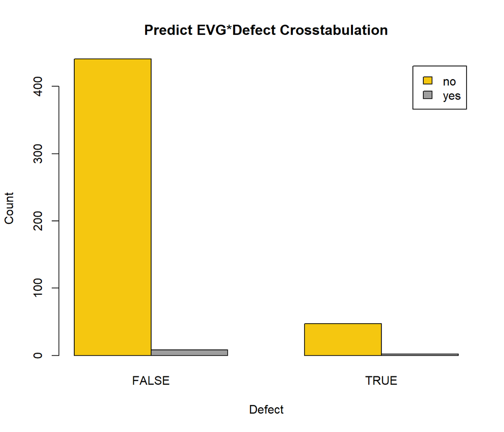

```r
tab=with(swd, table(predict.evg.14.5,defect))

barplot(tab, beside=TRUE, leg=TRUE,ylab = "Count", main="Predict EVG*Defect Crosstabulation", xlab="Defect", col=7:8)
```

```r
tab5=addmargins(tab)
tab5
```

```
##                 defect
## predict.evg.14.5 FALSE TRUE Sum
##              no    441   47 488
##              yes     8    2  10
##              Sum   449   49 498
```

```r
swd=read.csv("swdefects.csv")
head(swd)
```

|  | Mloc | Mvg | Mevg | Mivg | Hn | Hvol | Hpgmlen | Hdiff | Hintell | Heffort | Hb | Htime | Hloc | Hcomm | Hblank | loc.comm | uniOp | uniOpnd | totOp | totOpnd | brnchcnt | defect | predict.vg.10 | predict.evg.14.5 | predict.ivg.9.2 | predict.loc.50 |
| --- | --- | --- | --- | --- | --- | --- | --- | --- | --- | --- | --- | --- | --- | --- | --- | --- | --- | --- | --- | --- | --- | --- | --- | --- | --- | --- |
| 1 | 1.1 | 1.4 | 1.4 | 1.4 | 1.3 | 1.3 | 1.30 | 1.30 | 1.30 | 1 | 1.30 | 1 | 2 | 2 | 2 | 2 | 1.2 | 1.2 | 1.2 | 1.2 | 1.4 | FALSE | no | no | no | no |
| 2 | 1.0 | 1.0 | 1.0 | 1.0 | 1.0 | 1.0 | 1.00 | 1.00 | 1.00 | 1 | 1.00 | 1 | 1 | 1 | 1 | 1 | 1.0 | 1.0 | 1.0 | 1.0 | 1.0 | TRUE | no | no | no | no |
| 3 | 24.0 | 5.0 | 1.0 | 3.0 | 63.0 | 309.1 | 0.11 | 9.50 | 32.54 | 2937 | 0.10 | 163 | 1 | 0 | 6 | 0 | 15.0 | 15.0 | 44.0 | 19.0 | 9.0 | FALSE | no | no | no | no |
| 4 | 20.0 | 4.0 | 4.0 | 2.0 | 47.0 | 215.5 | 0.06 | 16.00 | 13.47 | 3448 | 0.07 | 192 | 0 | 0 | 3 | 0 | 16.0 | 8.0 | 31.0 | 16.0 | 7.0 | FALSE | no | no | no | no |
| 5 | 24.0 | 6.0 | 6.0 | 2.0 | 72.0 | 346.1 | 0.06 | 17.33 | 19.97 | 6000 | 0.12 | 333 | 0 | 0 | 3 | 0 | 16.0 | 12.0 | 46.0 | 26.0 | 11.0 | FALSE | no | no | no | no |
| 6 | 24.0 | 6.0 | 6.0 | 2.0 | 72.0 | 346.1 | 0.06 | 17.33 | 19.97 | 6000 | 0.12 | 333 | 0 | 0 | 3 | 0 | 16.0 | 12.0 | 46.0 | 26.0 | 11.0 | FALSE | no | no | no | no |

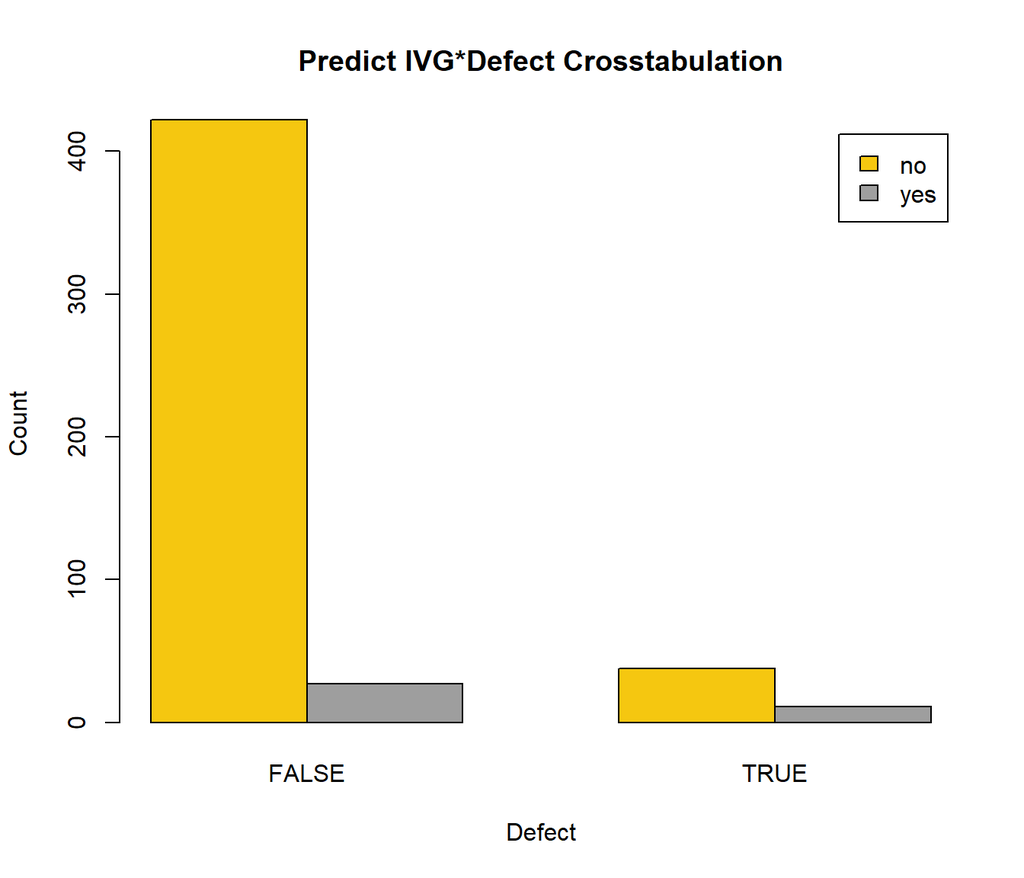

```r
tab=with(swd, table(predict.ivg.9.2,defect))

barplot(tab, beside=TRUE, leg=TRUE,ylab = "Count", main="Predict IVG*Defect Crosstabulation", xlab="Defect", col=7:8)
```

```r
tab6=addmargins(tab)
tab6
```

```
##                defect
## predict.ivg.9.2 FALSE TRUE Sum
##             no    422   38 460
##             yes    27   11  38
##             Sum   449   49 498
```

# 4 Create the corrected table on page 127 (there are mistakes in it), TABLE SIA3.3

Using the functions you have made, create the corrected table (SIA3.3) in an R chunk.

You can call this table `tab3`

Now create a function `mybar()`that will have as its input variables

> 1. tab ( this will be a n by m table) - like `tab3`
> 2. acc ( accuracy of the decimal output ) – like `acc=4` for example

The function will need to create two things

> 1. A barplot of the table
> 2. Commandline output in the form of a list containing the table

```r
accacc<-c(acc(400,29,49,20),acc(397,35,52,14),acc(441,47,8,2),acc(422,38,27,11))
accuracy <- round(accacc,4)
```

```r
detdet<-c(detect(29,20), detect(35,14) ,detect(47,2) ,detect(38,11))

detection.rate <- round(detdet,4)
```

```r
ffal<-c(

falarm(400,49),#loc far
falarm(397,52),
falarm(441,8),
falarm(422,27))

false.alarm.rate <- round(ffal,4)
```

```r
pprc <- c(

prec1(49,20),
prec1(52,14),
prec1(8,2),
prec1(27,11))

precision <- round(pprc,4)
```

```r
methodrow <- c("Lines of Code", "Cyclomatic complexity", "Essential complexity", "Design Complexity" )
row15 <- cbind(accuracy, detection.rate, false.alarm.rate, precision)
```

```r
correct25=read.csv("correct1.csv")
```

```r
tab<- row15
tab3 <- correct25
tab3
```

| ï..method | accuracy | detection.rate | false.alarm.rate | precision |
| --- | --- | --- | --- | --- |
| lines of code | 0.8434 | 0.4082 | 0.1091 | 0.2899 |
| cyclomatic complexity | 0.8253 | 0.2857 | 0.1158 | 0.2121 |
| essential complexity | 0.8896 | 0.0408 | 0.0178 | 0.2000 |
| design complexity | 0.8694 | 0.2245 | 0.0601 | 0.2895 |

[figure not shown]

```r
mybar=function(tab,acc)

{
barplot(tab, beside = TRUE, legend.text = methodrow, col=1:4)
  list(prjct1=tab3)

}
```